# Lab_3_Levy_Eden_And_Esudri_Shira

Eden Levy and Shira Esudri

20 6 2020

Q1- Value at risk or VAR is a measure of the risk of loss for investments and is widely used by financial institutions. Mathematically, Value at Risk at a given probability q estimates the loss/gain of a stock/portfolio/investment during a fixed time, such that the probability to suffer a higher loss is no more than q.

To describe the price of an asset over time, we will use a simplified version of a popular stochastic process model called Geometric Brownian motion. The Geometric Brownian Motion (GBM) describing the investment price follows a random walk with drift. That is, each movement from day to day is random and is independent of past price movements, and the movements follow the same distribution and may, on average, drift upwards or downwards.

We define our model to be St=St−1×(μ+σϵt), where: - St is the price at day t - μ is the relative expected daily change - σ is the standard deviations of the daily change - ϵt is the random variable determining the actual change in price at day t.

A- Use the command quantmod::getSymbols from the quantmod package to load into a data-frame called nasdaq the daily data of the NASDAQ index in the year 2020, starting from 2020-01-02. We will mostly work with the Adjusted price. Change the corresponding column name to price. Print the Nasdaq price levels at the first 10 trading days of 2020. Hint: xts cheat sheet

```r
library(quantmod)

rm(list=ls())
IXIC <- new.env()
#load data with quantmod
quantmod::getSymbols("^IXIC", env = IXIC, src = "yahoo", from = as.Date("2020-01-02"))
```

[output not shown]

```
## [1] "^IXIC"
```

```r
nasdaq <- IXIC$IXIC
str(nasdaq)#xts object
```

```
## An 'xts' object on 2020-01-02/2020-06-26 containing:
##   Data: num [1:123, 1:6] 9039 8976 8944 9077 9068 ...
##  - attr(*, "dimnames")=List of 2
##   ..$ : NULL
##   ..$ : chr [1:6] "IXIC.Open" "IXIC.High" "IXIC.Low" "IXIC.Close" ...
##   Indexed by objects of class: [Date] TZ: UTC
##   xts Attributes:
## List of 2
##  $ src    : chr "yahoo"
##  $ updated: POSIXct[1:1], format: "2020-06-28 17:18:54"
```

```r
#Change the Adjusted price column name to price
colnames(nasdaq) <-  c("Open","High","Low","Close","Volume","Price")

#Print the Nasdaq price levels at the first 10 trading days of 2020 by using xts cheat sheet
head(nasdaq$Price, 10)
```

```
##              Price
## 2020-01-02 9092.19
## 2020-01-03 9020.77
## 2020-01-06 9071.47
## 2020-01-07 9068.58
## 2020-01-08 9129.24
## 2020-01-09 9203.43
## 2020-01-10 9178.86
## 2020-01-13 9273.93
## 2020-01-14 9251.33
## 2020-01-15 9258.70
```

```r
# print_date<- as.character(index(nasdaq)[1:10])
# price<- as.vector(nasdaq$price[1:10])
# kable(cbind(Date = print_date, price))

#define the date variable
dates<- as.character(index(nasdaq))
```

B- Plot the Nasdaq prices and Volumes vs. their respective dates in 2020, in separate graphs. Next, calculate and plot the daily volatility, defined as the difference between the High and Low price for each day. Can you recognize from the plots global events?

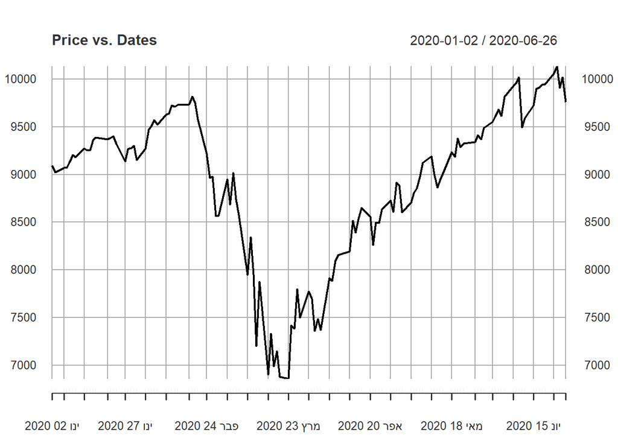

```r
#Plot the Nasdaq prices and Volumes vs. their respective dates in 2020, in separate graphs.
plot(nasdaq$Price,dates, main = "Price vs. Dates",xlab = "Price", ylab ="Date" )
```

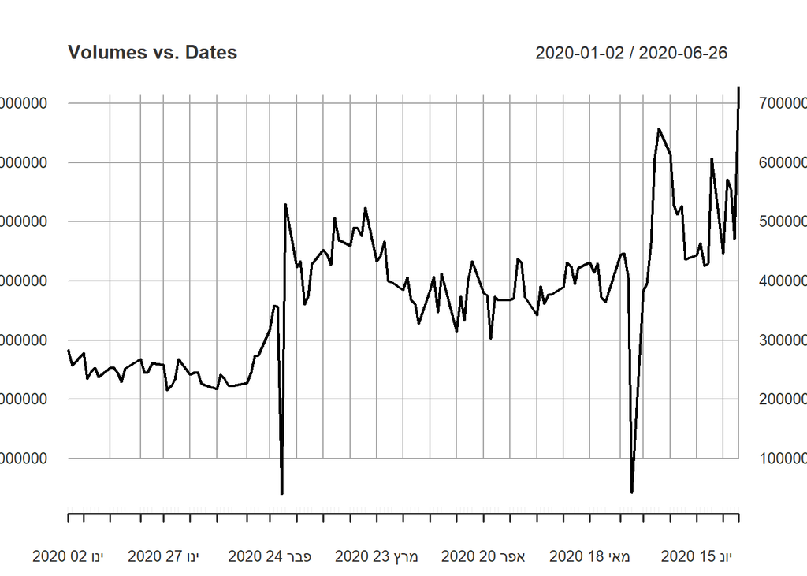

```r
plot(nasdaq$Volume,dates, main = "Volumes vs. Dates", xlab = "Volumes", ylab ="Date" )
```

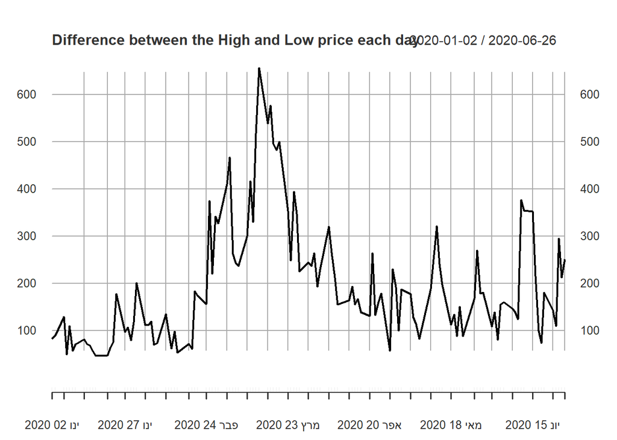

```r
#calculate the daily volatility, defined as the difference between the High and Low price for each day
daily_volatility<- round(nasdaq$High- nasdaq$Low,2)

#plot the daily volatility

plot(daily_volatility, dates , main ="Difference between the High and Low price each day", xlab = "Difference", ylab ="Date", ylim = c(0,660))
```